# 中垂線、垂線與角平分線作圖

> 來源整理：改國二下3_尺規作圖_易讀版.md

## 垂直、中垂線與角平分線

> 學習目標：垂直看 90 度，平分看分成兩個相等部分；中垂線同時具有垂直和平分。

### 先抓住核心

- 兩條直線或線段相交成直角，就稱互相垂直。
- 中垂線是線段的垂直平分線：垂直於線段，且通過線段中點。
- 中垂線上的任一點，到線段兩端點距離相等。
- 角平分線把一個角分成兩個相等的角。
- 作圖題常用等腰三角形、菱形或箏形的性質來得到垂直或平分。

### 作圖流程

1. 看到 90 度或直角符號，先想到垂直。
2. 看到中點、兩段相等，先想到平分。
3. 同時垂直又平分線段，就是中垂線。
4. 把角分成相等兩半，就是角平分線。

### 公式、性質與判斷

- **垂直**：兩線夾角為 90°。
- **中垂線**：垂直線段，且通過中點。
- **角平分線**：把一角分成兩個相等角。

### 例題拆解

- 若 P 是 AB 的中點，且直線 L 垂直 AB，則 L 是 AB 的中垂線。
- 若射線 BF 使角 ABF 與角 FBC 相等，則 BF 是角 ABC 的角平分線。

### 易錯提醒

- 只看到垂直就說是中垂線，忘記還要平分線段。
- 把角平分線和中線混淆，錯把角平分當成邊長平分。

### 小練一下

- 中垂線需要滿足哪兩個條件？
- 角平分線平分的是線段長度，還是角度？

### 記憶鉤子

- 中垂線不是只有『垂直』，還要『通過中點』。
- 角平分線分的是角，不是一定把對邊切成兩半。

### 圖像化理解

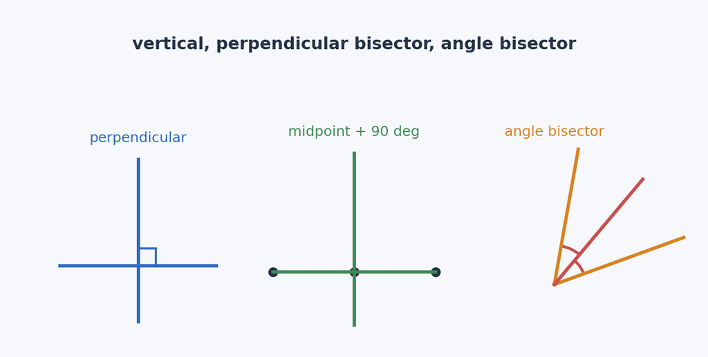

垂直、中垂線與角平分線

圖解：同圖比較垂直、中垂線、角平分線三個名詞。

## 過直線上一點作垂線

> 學習目標：點在直線上時，先在直線左右取等距兩點，再作這段線的中垂線。

### 先抓住核心

- 已知點 A 在直線 L 上，要作通過 A 且垂直 L 的直線。
- 以 A 為圓心畫弧，讓弧交 L 於 C、D 兩點，且 AC = AD。
- 再分別以 C、D 為圓心，用相同半徑畫弧，兩弧交於 E。
- 連接 A、E，得到的直線 AE 垂直 L。
- 理由是 A 是 CD 的中點，而 AE 是 CD 的中垂線。

### 作圖流程

1. 以 A 為圓心畫弧，交 L 於 C、D。
2. 以 C、D 為圓心，同半徑畫弧，交於 E。
3. 連接 A、E。
4. AE 就是過 A 且垂直 L 的直線。

### 公式、性質與判斷

- **核心**：先做出 CD，使 A 是 CD 中點。
- **結論**：AE 垂直 L。

### 例題拆解

- 若 A 在 L 上，左右等距取 C、D 後，A 是 CD 中點。
- 兩個同半徑弧交點 E 到 C、D 等距，因此 E 在 CD 的中垂線上。

### 易錯提醒

- C、D 沒有取在直線 L 上，最後垂線就沒有對準 L。
- 第二次畫弧半徑不相同，會破壞中垂線理由。

### 小練一下

- 第一步為什麼要讓 C、D 距離 A 一樣遠？
- 最後連接哪兩點得到垂線？

### 記憶鉤子

- 線上一點作垂線的套路：左右等距，再找弧交點。
- 這個作法其實是在作 CD 的中垂線。

### 圖像化理解

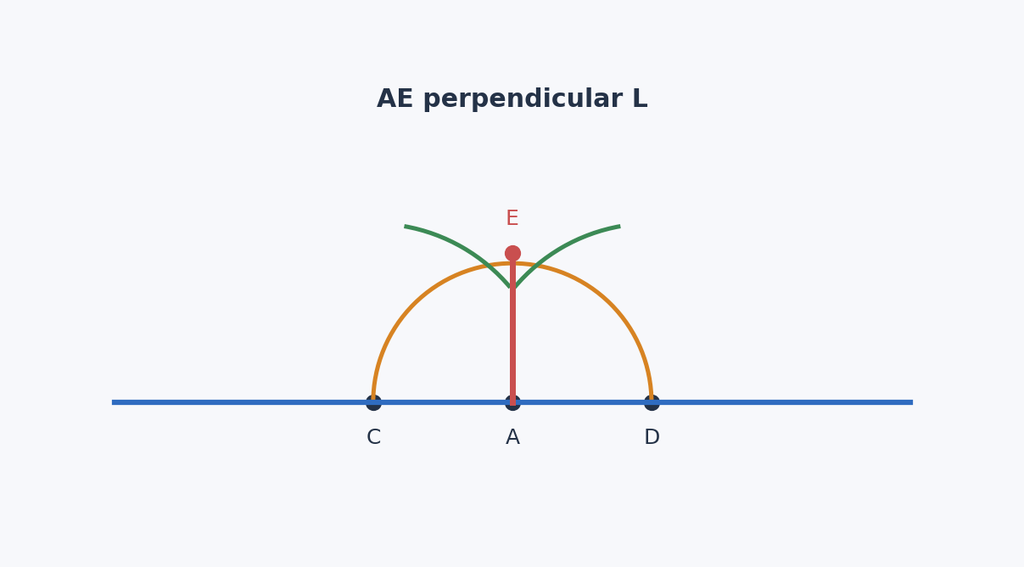

過直線上一點作垂線

圖解：用 C、D 對稱於 A 的作法，畫出過線上一點的垂線。

## 過直線外一點作垂線

> 學習目標：點在直線外時，先讓這個點連到直線上的兩個等距點，再用弧交點決定垂線。

### 先抓住核心

- 已知點 A 在直線 L 外，要作通過 A 且垂直 L 的直線。
- 以 A 為圓心畫弧，交直線 L 於 B、C 兩點，得到 AB = AC。
- 以 B、C 為圓心、相同半徑畫弧，兩弧在另一側交於 D。
- 連接 A、D，則 AD 垂直 L。
- 理由可用等腰三角形或箏形的對稱性理解。

### 作圖流程

1. 以外點 A 為圓心畫弧，交 L 於 B、C。
2. 以 B、C 為圓心，同半徑畫弧，交於 D。
3. 連接 A、D。
4. AD 就是通過 A 且垂直 L 的直線。

### 公式、性質與判斷

- **等距**：AB = AC，DB = DC。
- **結論**：AD 垂直 L。

### 例題拆解

- A 與 D 都到 B、C 等距，所以 A、D 都在 BC 的中垂線上。
- 連 AD 就是 BC 的中垂線，而 BC 在 L 上，因此 AD 垂直 L。

### 易錯提醒

- 第一個弧半徑太短沒有交到 L，作圖無法進行。
- B、C 的弧用不同半徑，會失去 DB = DC 的等距條件。

### 小練一下

- 第一個弧必須交直線 L 於幾個點？
- 連接 A 與哪一個點得到垂線？

### 記憶鉤子

- 線外點作垂線的關鍵：讓外點 A 也成為等距點。
- A、D 同時到 B、C 等距，所以 AD 是 BC 的中垂線。

### 圖像化理解

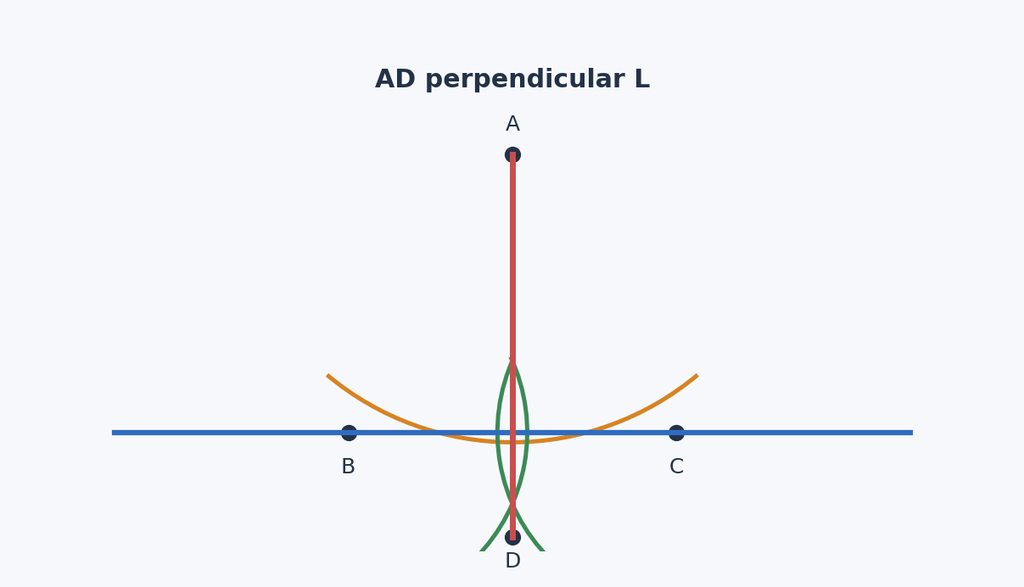

過直線外一點作垂線

圖解：從線外點 A 出發，透過 B、C 與弧交點 D 作出垂線。

## 作線段中點、中垂線與四等分

> 學習目標：線段中點可以用中垂線取得；要四等分，就對半再對半。

### 先抓住核心

- 已知線段 AB，要找中點 M，可分別以 A、B 為圓心畫同半徑弧。
- 半徑要大於 AB 的一半，兩組弧才會在上下交於兩點。
- 連接兩個弧交點，這條線就是 AB 的中垂線。
- 中垂線與 AB 的交點 M，就是 AB 的中點。
- 要將 AB 四等分，先找 AB 中點，再分別找 AM 與 MB 的中點。

### 作圖流程

1. 以 A、B 為圓心，用同半徑畫弧，上下交於 P、Q。
2. 連接 P、Q，得到 AB 的中垂線。
3. PQ 與 AB 交於 M，M 是 AB 中點。
4. 四等分時，再對 AM、MB 各作一次中垂線。

### 公式、性質與判斷

- **中點**：AM = MB。
- **中垂線**：垂直 AB 且通過中點 M。
- **四等分**：先二等分，再二等分兩半。
- **2^n 等分**：需連續二分，總作中垂線次數可用 2^n - 1 理解。

### 例題拆解

- 作 AB 的中垂線後，交點 M 使 AM = MB。
- 若要四等分 AB，得到的三個分點把 AB 分成四段等長。

### 易錯提醒

- 半徑太短導致兩弧不相交。
- 只找出中垂線，卻忘了中點是中垂線與原線段的交點。

### 小練一下

- 作中垂線時，圓規半徑為什麼要大於 AB 的一半？
- 四等分一條線段，需要先做什麼？

### 記憶鉤子

- 中垂線是找中點最穩的工具。
- 四等分不要硬量，把一半再切一半就好。

### 圖像化理解

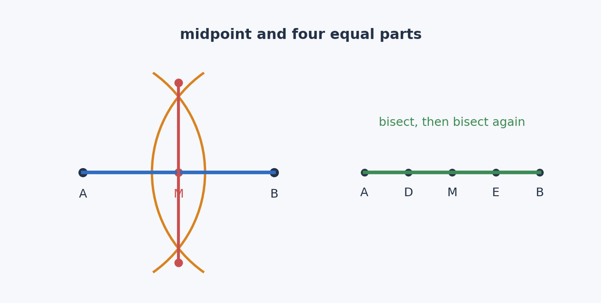

作線段中點、中垂線與四等分

圖解：用兩組等半徑弧作中垂線，再示意四等分是連續二等分。

## 作角平分線

> 學習目標：角平分線作圖的核心，是先在角的兩邊取等距點，再用兩點作等距交點。

### 先抓住核心

- 已知角 ABC，要作它的角平分線。
- 以 B 為圓心畫弧，交角的兩邊於 D、E，得到 BD = BE。
- 以 D、E 為圓心，用相同半徑畫弧，兩弧在角內交於 F。
- 連接 B、F，則 BF 平分角 ABC。
- 這個作法可用菱形或全等三角形的想法理解。

### 作圖流程

1. 以角頂點 B 為圓心畫弧，交兩邊於 D、E。
2. 以 D、E 為圓心，同半徑畫弧，交於 F。
3. 連接 B、F。
4. BF 就是角 ABC 的角平分線。

### 公式、性質與判斷

- **等距**：BD = BE，DF = EF。
- **結論**：角 ABF = 角 FBC。

### 例題拆解

- 若角 ABC 是 70 度，作出角平分線 BF 後，兩邊各為 35 度。
- F 到 D、E 等距，B 到 D、E 也等距，因此 BF 具有對稱效果。

### 易錯提醒

- D、E 沒有取在角的兩邊上，會失去 BD = BE 的基礎。
- 第二次畫弧半徑不同，導致 F 不一定在對稱位置。

### 小練一下

- 角平分線作圖第一個圓心是哪一點？
- 最後連接哪兩點得到角平分線？

### 記憶鉤子

- 角平分線的套路：頂點畫弧，兩邊交點再畫弧，頂點連交點。
- 要平分的是角度，不是一定平分對邊。

### 圖像化理解

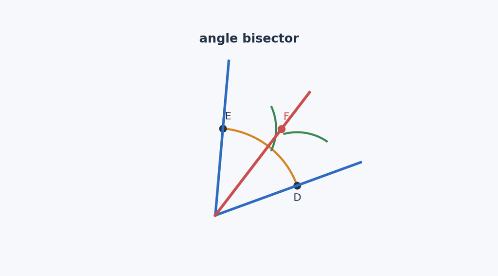

作角平分線

圖解：用 D、E 等距點與弧交點 F 作出角平分線。